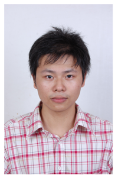

# 吴 晓

## 图形工程师

- 电话: 86-15861657693
- 邮件: tinysilk@hotmail.com
- 博客（墙外）: tinyslik.github.io
- 博客（墙内）: tinyslik.coding.me
- Github: TinySlik

## 特长

能胜任android（java），ios（OC）单平台或者跨平台C++的开发工作，对css，html5，js均有良好的掌握度，能够进行前端开发；  
对openGL有良好的掌握度，对shader优化编写使用熟练。对图形数学有良好的认识和基础。 长期使用cocos2d-x,uinity3d游戏引擎，对游戏引擎的工具编写也有良好的习惯。

## 工作经验

### **cocos2d-x 开发工程师** 在 [MoChang有限公司](https://www.mochang.net/)

*2014.1 - 2015.6*

1.在公司主要从事cocos2d-x游戏的制作和维护工作，使用C++重构代码，配置更多的功能模块. 2.作为从事生物科技工作的我来说，这是一次挑战，我学习到了很多C++基本的语法及表驱动，插件架构等常用的语言设计模式。补习了很多程序及系统的基础原理，对linux系统的学习了一段时间，能独立编写小型的c++服务器。 3.在公司我工作了一年半，上架了一些比较简单的欧美儿童游戏，有大量的功能模块重用和维护。 4.期间也独立完成很多 ios 及安卓端的 sdk包括广告的和功能的接入。 5.制作小型游戏制定文档并按照需求文档在较短的时间内提交上线。 6.由于团队小，所以大量的与美术的协调工作都由我独立完成，团队的策划担任高层领导角色，团队具有比较高的自由度。

### **C/C++ 开发工程师** 在 [南京光辉互动网络科技有限公司](https://bie-plc.com/)/[熊大叔儿童教育](https://www.biemore.com/zh-cn/index.html)

*2015.6 - 2016.2*

1.一线开发游戏项目，对多个产品线不同语言的项目代码进行检查和修改重构，使用代码包括包括js,Lua,C++。 2.实现shader技术优化和难点。 3.负责一些产品最后阶段的代码调试和检查工作，接入一些商业代码,sdk。

### **前端工程师兼培训师** 在 [南京触控科技办事处](http://www.chukong-inc.com/)

*2016.3 - 2016.10*

1.参与3.x的cocos2d-x引擎代码的修改和维护，上架一些以前的成品代码游戏。 2.培训新员工，培训git，lua,quick-cocos部分内容。 3.修改和上线u3d项目.

### 主要语言技能

注：  
+：使用过，了解语法，能够上手修改现有的浅层代码逻辑  
++：全盘学习过，理解语言全盘的语法，对语言的相关设计理念有认识，对相关特性够熟练运用 +++：相关语言的基本设计模式能够完全应用于实践，能够胜任框架的搭建

- [C++](http://www.cplusplus.com/)+++
- C++
- [Lua](http://www.lua.org/)+++
- [java](https://www.java.com/zh_CN/)+
- [objective-C](https://developer.apple.com/)+
- [C#](https://www.microsoft.com/net/)++
- [shader](https://www.glslsandbox.com/)+++
- [javaScript](https://www.javascript.com/)++
- [HTML](http://developers.whatwg.org)++
- [CSS](http://www.w3.org/Style/CSS/Overview.en.html)+
- [python](https://www.python.org/)+
- [Ruby (Rake)](http://www.ruby-lang.org/zh_cn/)++
- [UML](http://www.uml.org/)+

### 格式类型使用

注：  
+：了解并修改过小于5次。 ++：全盘学习过，熟练使用语法书写内容或修改配置。 +++：查看过底层格式实现原理，并修改使用过自己的衍生格式。

- [Markdown](http://daringfireball.net/projects/markdown)++
- [XML](https://www.xml.com/)+
- [Jason](http://www.json.org.cn/)++
- [ini](https://github.com/Winnerhust/inifile2)++

### 框架

注*：  
+：使用过，了接口用法，能够快速使用。 ++：模块化地学习过，理解框架下原理，能够熟练进行相关优化。 +++：查看学习过框架源码，修改框架内部实现并商用化过相关的代码。

- [OpenGL （web,ES,glut,glew,glsl…）](https://www.opengl.org/)++
- [openCV](http://opencv.org/)+
- [Boost (shared_ptr,λ,tuple,thread…)](http://www.boost.org/)++
- [Cocos2d-x](http://www.cocos2d-x.org/)+++
- [Uinity3d](https://unity3d.com/cn/)++
- [hexo](https://hexo.io/)++
- http,tcp/ip,udp+

### 软件

注*：  
+：使用过，能够完成常规的工具功能 ++：熟练使用，包括快捷键和高度自定义的功能 +++：查看过软件源码，修改衍生过相关的商用版本

- IDE:[Apple Xcode](http://developer.apple.com)++/[VisualStudio](https://www.visualstudio.com/)++/[AndroidStudio](http://www.android-studio.org/)+
- [Git](http://git-scm.com)++
- [Subversion](http://svn.apache.org)+
- [SourceTree(win)](https://www.sourcetreeapp.com/)/[Tower(mac)](https://www.git-tower.com/)++
- [JIRA](http://atlassian.com/software/jira)+
- [grub/grub2](http://www.gnu.org/software/grub/)++
- [Mac OS X](http://apple.com/macosx)++/[Ubuntu Linux](http://ubuntu.com)++
- [Sublime Text](http://www.sublimetext.com)++
- [Vim](http://www.vim.org)++
- [zsh](http://www.zsh.org)++
- [bash](http://www.gnu.org/software/bash/)++
- [WebStorm](http://jetbrains.com/webstorm)+
- [Pandoc](http://johnmacfarlane.net/pandoc)+
- [Doxygen](https://github.com/doxygen/doxygen)+
- [Latex](http://www.latex-project.org/)+
- [Nginx](http://wiki.nginx.org)+
- [MySQL](http://mysql.com)+

## 教育

扬州大学 动物医学, 2008 - 2012

## 兴趣

- 玩卡牌游戏（炉石）,至今未上传说…
- 听音乐,玩一些器材,中西内外新旧都听
- 养猫,叫毛毛,一只英短蓝色的小母猫
- 弹吉他,准备周末去卖艺
- 逛github,知乎,Bilibili 找基佬玩耍
- 另外已婚未育

## 下载

以下是我的多种格式下的简历，如有需要请自行下载：

[doc](https://github.com/TinySlik/resume/raw/master/resume_cn.docx)

[ePub](https://github.com/TinySlik/resume/raw/master/resume_cn.epub)

谢谢对我的关注.

©2016 [Tiny Oh](http://tinyslik.coding.me/resume). All rights reserved.